# Stock_Twits_Sentiment_Analysis

```
## [1] 135829
```

### Methodology for extraction of Data - StockTwits

We follwed a similar approach as for Twitter data to collect tweets for the chosen stocks for three weeks from [StockTwits](https://api.stocktwits.com/api/2/streams/symbol/AAPL.json). The data gathering, cleaning and processing steps can be summarized as below

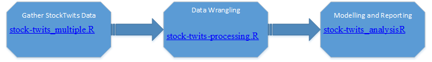

In the stock-twits_multiple.R file we make an API call, to StockTwits for a given symbol every 15 minutes for 3 weeks, that returns response in JSON. We use **rjson** library to extract the id, message, timestamp and symbol from the JSON response and converted the UTC time to EST time as shown below.

```r
head(data, n=5) %>% kable
```

| id | message | createdat | symbol | sentiment_score | utc.time | est.time | est.date | est.date.plus.one | est.hour |
| --- | --- | --- | --- | --- | --- | --- | --- | --- | --- |
| 52295991 | Cheap put options and hedges: $SLV puts cheaper than 93% of history, $DAL 92%, $BBRY 89%, $MAS 88%, $GILD 86%, $CSCO 84%, $AAPL 84% | 2016-04-05 02:19:02 | GILD | 0 | 2016-04-05 02:19:02 | 2016-04-04 22:19:02 | 4/04/2016 | 4/05/2016 | 4/04/2016 22 |
| 52294132 | $GILD coming back to you beautiful fwd pe gild. Allergan got decapitated. Now i will trade amgn gild and uvxy | 2016-04-05 01:31:35 | GILD | 1 | 2016-04-05 01:31:35 | 2016-04-04 21:31:35 | 4/04/2016 | 4/05/2016 | 4/04/2016 21 |
| 52294103 | $XBI 10000+ CALLS $ICPT $IBB $GILD $TWTR+8% $SPY $IWM $QQQ SECTOR ANALYSIS- LEVELS/PATTERN/OPTIONS FLOW http://stkw.it/z4xh | 2016-04-05 01:30:55 | GILD | 0 | 2016-04-05 01:30:55 | 2016-04-04 21:30:55 | 4/04/2016 | 4/05/2016 | 4/04/2016 21 |
| 52293327 | @BrackAttack That I wake up ready to roll. Think biopharma goes higher in q2. $gild $celg favorites. $agn just spec on big selloff. | 2016-04-05 01:09:05 | GILD | 4 | 2016-04-05 01:09:05 | 2016-04-04 21:09:05 | 4/04/2016 | 4/05/2016 | 4/04/2016 21 |
| 52292438 | $GILD http://stkw.it/z4xA | 2016-04-05 00:41:33 | GILD | 0 | 2016-04-05 00:41:33 | 2016-04-04 20:41:33 | 4/04/2016 | 4/05/2016 | 4/04/2016 20 |

Next we aggregate collected data in stock-twits-processing.R file and cleanup duplicate messages. We then calculate the sentiment score for each tweet( or message) by taking the counts of postive terms minus the counts of negative terms in a tweet as explained in a paper [here](http://www.r-bloggers.com/an-example-on-sentiment-analysis-with-r/). We used [AFINN](http://www2.imm.dtu.dk/pubdb/views/publication_details.php?id=6010) word list and English Opinion Lexicon positive and negative word lists to compare the words in a tweet to determine if it is a postiver term or a negative term to calculate the sentiment score.

In the final modelling step in stock-twits-analysis.R file, we combine the StockTwits data and [Yahoo! finance data](https://github.com/goodwillyoga/E107project/blob/master/pulkit/yahoo-finance.RData) to model the stock price based on the tweet counts and sentiment scores. (The Yahoo finance data is in the EST timezone and we converted the StockTwits timestanp into EST timestamp also.)

Next we proceed with exploratory data analysis.

#### Exploratory Data Analysis for Stock Twits Data

1. We plotted heatmap to show the stock price and tweet counts for all chosen symbols. The area for each symbol in the heatmap represents the price of the stock for a given day. The color scale represents the tweet counts with lighter green reperenting more number of tweet counts for a given symbol. (This data visualization be extended to a Shiny app in the future, where we can present user a date picker and they can see the heatmap for a given day)

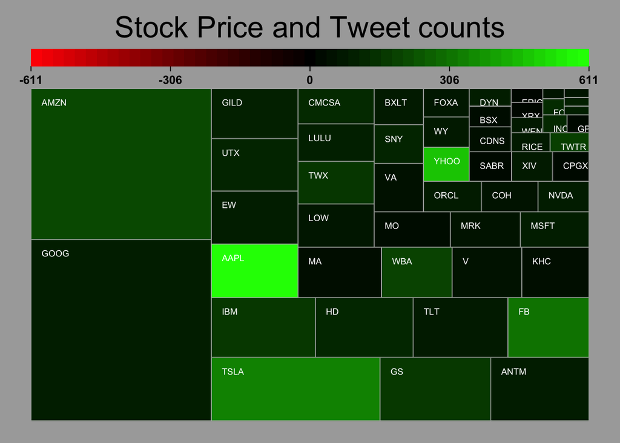

2. We plotted the heatmap for the top 50 positive and negative matched words in StockTwits messages. The area and color in the heatmap represents the counts for matched words.

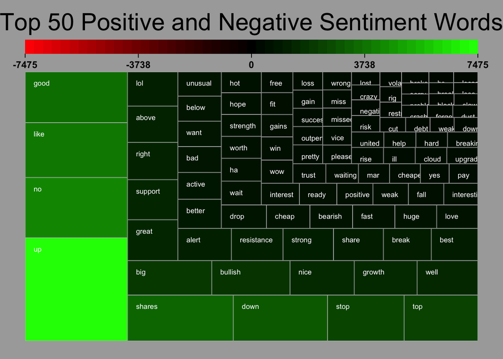

3. We plotted the density plot of normalized hourly percent change in sentiment score and price change for three chosen stocks (EIX, IBM, and GS).

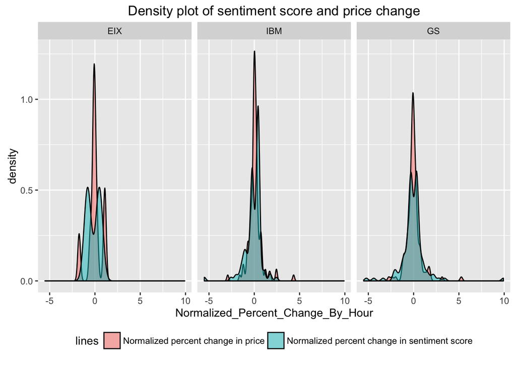

4. We plotted the histogram of sentiment score.

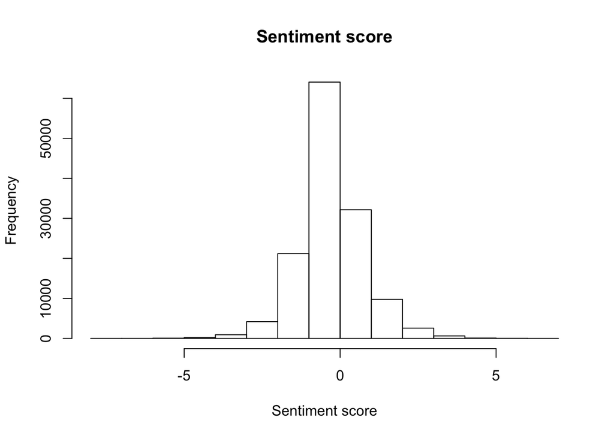

#### Modeling hourly and daily stock price and volume change by sentiment score and tweet counts

1. We fit the linear regression model for **daily stock price change** by sentiment score and tweet counts.

| symbol | term | estimate | std.error | statistic | p.value |
| --- | --- | --- | --- | --- | --- |
| AMZN | scale_pchange_tweet_counts | 0.6766891 | 0.1355977 | 4.990416 | 0.0001613 |
| BSX | scale_pchange_tweet_counts | 0.8223642 | 0.2905773 | 2.830104 | 0.0126659 |
| DYN | scale_pchange_avg_score | 0.4193759 | 0.1822659 | 2.300902 | 0.0361612 |
| EIX | scale_pchange_avg_score | 1.2897221 | 0.2960962 | 4.355753 | 0.0024264 |
| ERIC | scale_pchange_tweet_counts | -1.0120269 | 0.1653136 | -6.121862 | 0.0000264 |
| GRPN | scale_pchange_tweet_counts | -0.6678437 | 0.1186102 | -5.630575 | 0.0000479 |
| IBM | scale_pchange_tweet_counts | -0.6733958 | 0.1372567 | -4.906107 | 0.0001901 |
| INO | scale_pchange_tweet_counts | -0.4231592 | 0.1951766 | -2.168084 | 0.0466463 |
| LOW | scale_pchange_tweet_counts | 1.1064018 | 0.4406972 | 2.510571 | 0.0239995 |
| LULU | scale_pchange_avg_score | 0.6497194 | 0.2169601 | 2.994649 | 0.0090710 |
| TSLA | scale_pchange_tweet_counts | -0.6415539 | 0.2947909 | -2.176302 | 0.0459231 |
| VA | scale_pchange_avg_score | 0.4632057 | 0.1936315 | 2.392203 | 0.0302828 |
| WBA | scale_pchange_tweet_counts | -0.4709600 | 0.1967329 | -2.393906 | 0.0312313 |

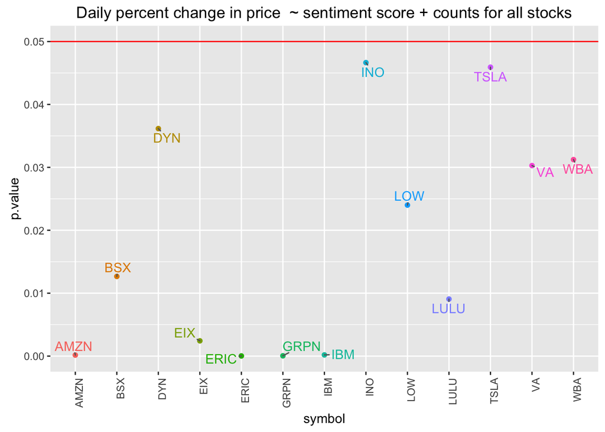

2. We fit the linear regression model for **daily stock volume change** by sentiment score and tweet counts.

[output not shown]

[figure not shown]

3. We fit the linear regression model for **hourly stock price change** by sentiment score and tweet counts.

| symbol | term | estimate | std.error | statistic | p.value |
| --- | --- | --- | --- | --- | --- |
| AVP | scale_pchange_avg_score | 0.3727135 | 0.1286469 | 2.897183 | 0.0059012 |
| AVP | scale_pchange_tweet_counts | 0.2386057 | 0.1111294 | 2.147098 | 0.0374666 |
| AXLL | scale_pchange_avg_score | -1.8420821 | 0.5188298 | -3.550455 | 0.0120654 |
| AXLL | scale_pchange_tweet_counts | -2.0008606 | 0.7620122 | -2.625759 | 0.0392820 |
| ERIC | scale_pchange_tweet_counts | -0.7564934 | 0.2512391 | -3.011049 | 0.0045507 |
| FB | scale_pchange_avg_score | 0.2513207 | 0.0830096 | 3.027612 | 0.0031427 |
| FOLD | scale_pchange_avg_score | -0.4826845 | 0.1471095 | -3.281124 | 0.0017530 |
| FOXA | scale_pchange_avg_score | -0.3570588 | 0.1313681 | -2.718002 | 0.0106547 |
| LULU | scale_pchange_avg_score | -1.5666647 | 0.3640209 | -4.303776 | 0.0000681 |
| LULU | scale_pchange_tweet_counts | -0.3271885 | 0.0976415 | -3.350916 | 0.0014475 |
| MO | scale_pchange_tweet_counts | -0.2103006 | 0.0902013 | -2.331460 | 0.0223463 |
| ORCL | scale_pchange_avg_score | 0.4099242 | 0.1622587 | 2.526362 | 0.0150301 |
| PGR | scale_pchange_tweet_counts | 2.1570504 | 0.7539579 | 2.860969 | 0.0458846 |
| TWTR | scale_pchange_tweet_counts | -0.8670294 | 0.3724779 | -2.327734 | 0.0214589 |
| XRX | scale_pchange_avg_score | -0.5010891 | 0.1078631 | -4.645603 | 0.0000934 |

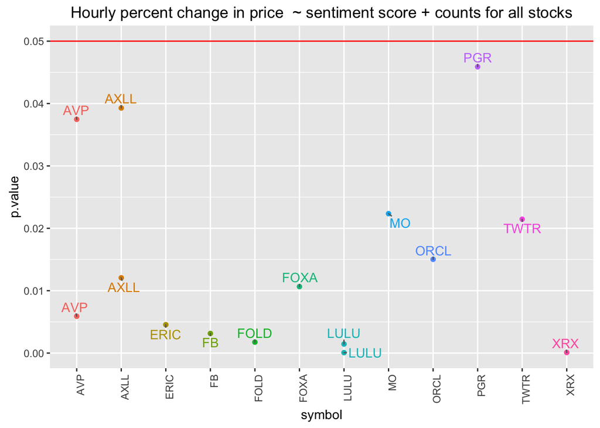

4. We fit the linear regression model for **hourly stock volume change** by sentiment score and tweet counts.

| symbol | term | estimate | std.error | statistic | p.value |
| --- | --- | --- | --- | --- | --- |
| AVP | scale_pchange_tweet_counts | 0.5362904 | 0.0734192 | 7.304500 | 0.0000000 |
| COH | scale_pchange_tweet_counts | 0.6835100 | 0.1531251 | 4.463737 | 0.0000322 |
| ERIC | scale_pchange_tweet_counts | 1.0988303 | 0.3828689 | 2.869991 | 0.0065981 |
| GNCA | scale_pchange_tweet_counts | 0.5127101 | 0.1741329 | 2.944360 | 0.0040685 |
| HD | scale_pchange_tweet_counts | 0.2425992 | 0.1062946 | 2.282328 | 0.0259704 |
| LULU | scale_pchange_tweet_counts | 1.0063701 | 0.1439110 | 6.993004 | 0.0000000 |
| MAS | scale_pchange_avg_score | -0.3786432 | 0.1636806 | -2.313306 | 0.0309273 |
| TWX | scale_pchange_tweet_counts | 0.3063015 | 0.1239455 | 2.471259 | 0.0170644 |
| WBA | scale_pchange_avg_score | 0.8127886 | 0.3611401 | 2.250619 | 0.0309887 |

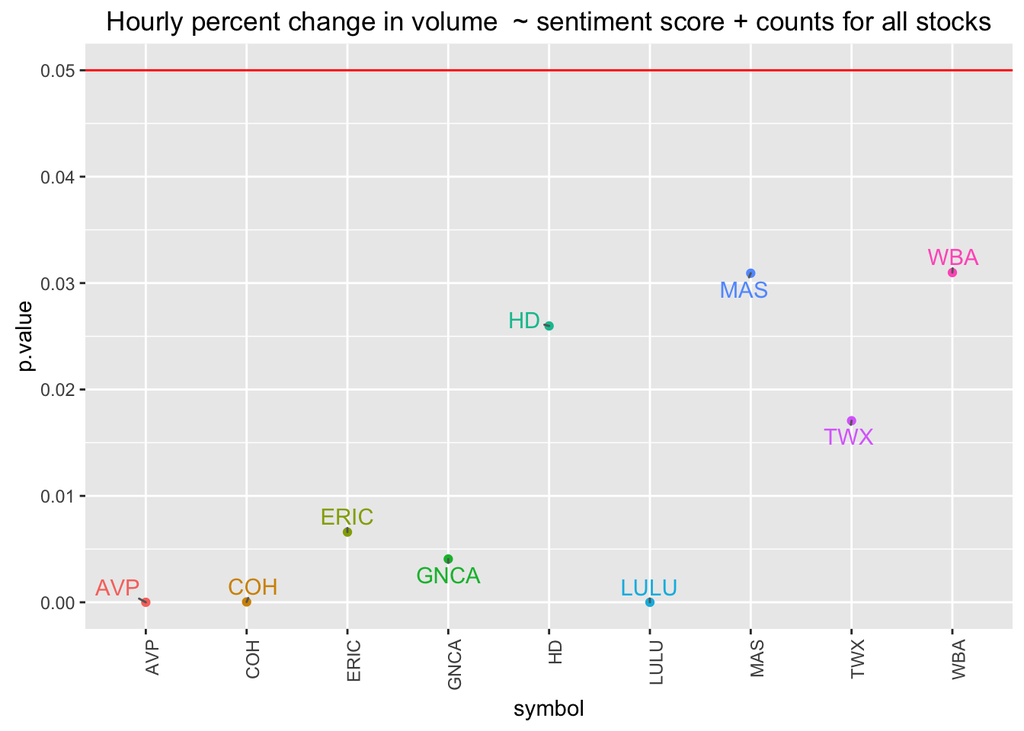

5. We fit the linear regression model for _**previous day close price** using previous day’s sentiment scores and counts.

| symbol | term | estimate | std.error | statistic | p.value |
| --- | --- | --- | --- | --- | --- |
| AAPL | avg_score | 27.8574370 | 5.6582155 | 4.923361 | 0.0000248 |
| AAPL | tweet_counts | -0.0036745 | 0.0015686 | -2.342520 | 0.0255363 |
| AVP | avg_score | 0.1085942 | 0.0394384 | 2.753516 | 0.0099149 |
| AVP | tweet_counts | 0.0010395 | 0.0002917 | 3.564086 | 0.0012452 |
| AXLL | tweet_counts | -0.0125323 | 0.0032930 | -3.805752 | 0.0015538 |
| CPGX | tweet_counts | -0.0015759 | 0.0005677 | -2.775891 | 0.0120389 |
| ERIC | avg_score | -0.7419820 | 0.2928032 | -2.534064 | 0.0176397 |
| FAF | avg_score | 2.8650000 | 1.0736689 | 2.668420 | 0.0444326 |
| FB | avg_score | 6.6541619 | 2.3978247 | 2.775083 | 0.0091386 |
| FOLD | avg_score | 0.2798826 | 0.0854461 | 3.275547 | 0.0026635 |
| FOLD | tweet_counts | 0.0009070 | 0.0004152 | 2.184351 | 0.0368862 |
| FOXA | tweet_counts | -0.0139308 | 0.0041047 | -3.393862 | 0.0018530 |
| GNCA | tweet_counts | 0.0053980 | 0.0012861 | 4.197151 | 0.0002007 |
| KHC | avg_score | 0.4995229 | 0.2194702 | 2.276039 | 0.0329321 |
| LULU | avg_score | 1.8284536 | 0.7296564 | 2.505911 | 0.0173230 |
| LULU | tweet_counts | -0.0104314 | 0.0045326 | -2.301425 | 0.0278198 |
| MA | tweet_counts | -0.0212416 | 0.0076803 | -2.765730 | 0.0093519 |
| NVDA | tweet_counts | -0.0055471 | 0.0015946 | -3.478746 | 0.0014750 |
| OCLR | avg_score | 0.1128993 | 0.0435499 | 2.592413 | 0.0145868 |
| ORCL | tweet_counts | 0.0035220 | 0.0016517 | 2.132317 | 0.0407529 |
| RTN | avg_score | 0.9000126 | 0.3363872 | 2.675526 | 0.0127371 |
| RTN | tweet_counts | -0.0071568 | 0.0032230 | -2.220541 | 0.0353056 |
| TSLA | tweet_counts | 0.0106024 | 0.0023198 | 4.570312 | 0.0000690 |
| TWTR | avg_score | 2.0946710 | 0.9232908 | 2.268701 | 0.0301687 |
| VA | tweet_counts | -0.0015967 | 0.0004758 | -3.356110 | 0.0021585 |
| WBA | tweet_counts | 0.0061984 | 0.0012803 | 4.841258 | 0.0000338 |
| XIV | avg_score | 3.4124005 | 1.1369980 | 3.001237 | 0.0052722 |
| XIV | tweet_counts | -0.0205986 | 0.0053688 | -3.836734 | 0.0005738 |

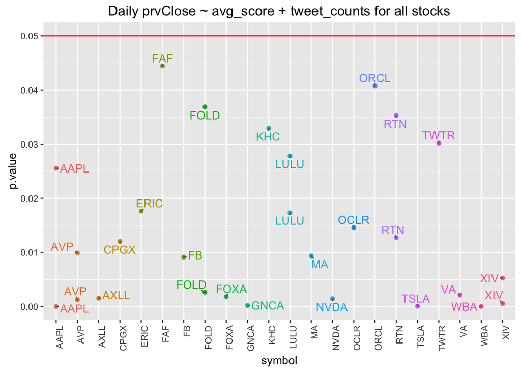

6. Lastly we fit the linear regression model for _**daily stock price** using the previous close price, sentiment score and tweet counts.

| symbol | term | estimate | std.error | statistic | p.value |
| --- | --- | --- | --- | --- | --- |
| AAPL | prvClose | 1.0060931 | 0.1093156 | 9.203567 | 0.0000003 |
| AMZN | prvClose | 0.5926640 | 0.2716815 | 2.181466 | 0.0466928 |
| ANTM | prvClose | 1.0340212 | 0.2857932 | 3.618074 | 0.0055885 |
| AVP | prvClose | 1.0885423 | 0.2008808 | 5.418846 | 0.0001173 |
| AXLL | prvClose | 1.0044606 | 0.0897775 | 11.188336 | 0.0000304 |
| BSX | prvClose | 1.0204499 | 0.0205761 | 49.593974 | 0.0000000 |
| BXLT | prvClose | 0.7870770 | 0.2598548 | 3.028911 | 0.0096851 |
| CDNS | prvClose | 1.2755840 | 0.2314642 | 5.510935 | 0.0008961 |
| CMCSA | prvClose | 0.8773383 | 0.1474030 | 5.951969 | 0.0000354 |
| COH | prvClose | 0.9710286 | 0.1198301 | 8.103377 | 0.0000019 |
| CPGX | prvClose | 0.8336199 | 0.0859946 | 9.693866 | 0.0000010 |
| DYN | prvClose | 0.9690273 | 0.0503382 | 19.250342 | 0.0000000 |
| EIX | prvClose | 0.6753250 | 0.2107106 | 3.204988 | 0.0149618 |
| ERIC | prvClose | 0.9616910 | 0.1161973 | 8.276365 | 0.0000015 |
| ERIC | tweet_counts | -0.0026851 | 0.0011783 | -2.278896 | 0.0402011 |
| EW | prvClose | 1.0572934 | 0.1747909 | 6.048903 | 0.0000299 |
| FB | prvClose | 1.0407118 | 0.1137714 | 9.147390 | 0.0000003 |
| FOLD | prvClose | 0.8627403 | 0.1581014 | 5.456881 | 0.0000845 |
| FOXA | prvClose | 1.0656504 | 0.0555460 | 19.185023 | 0.0000000 |
| FOXA | tweet_counts | 0.0028552 | 0.0013103 | 2.179078 | 0.0469018 |
| GILD | prvClose | 0.9273418 | 0.1882336 | 4.926547 | 0.0002767 |
| GILD | tweet_counts | -0.0198715 | 0.0058962 | -3.370220 | 0.0050216 |
| GNCA | prvClose | 0.8371074 | 0.1081665 | 7.739061 | 0.0000020 |
| GOOG | prvClose | 0.9635455 | 0.1208506 | 7.973029 | 0.0000014 |
| GRPN | prvClose | 1.2641379 | 0.3640871 | 3.472076 | 0.0037370 |
| GS | prvClose | 0.9593725 | 0.0514883 | 18.632824 | 0.0000000 |
| GS | avg_score | 4.9753003 | 1.9587312 | 2.540063 | 0.0235671 |
| HD | prvClose | 0.6623593 | 0.1820528 | 3.638281 | 0.0026866 |
| INO | prvClose | 0.9397618 | 0.0674325 | 13.936343 | 0.0000000 |
| KHC | prvClose | 0.9027474 | 0.1879142 | 4.804040 | 0.0009683 |
| LOW | prvClose | 0.7759829 | 0.1495310 | 5.189446 | 0.0001372 |
| LULU | prvClose | 0.9873153 | 0.1075216 | 9.182480 | 0.0000003 |
| MA | prvClose | 1.0028821 | 0.0649530 | 15.440108 | 0.0000000 |
| MAS | prvClose | 0.9675866 | 0.1762756 | 5.489055 | 0.0001893 |
| MO | prvClose | 0.9831254 | 0.1163306 | 8.451133 | 0.0000007 |
| MRK | prvClose | 1.0802512 | 0.0994480 | 10.862475 | 0.0000000 |
| MRK | avg_score | 0.2686819 | 0.1192860 | 2.252417 | 0.0408672 |
| MRK | tweet_counts | 0.0027113 | 0.0009103 | 2.978300 | 0.0099712 |
| MSFT | prvClose | 1.0534156 | 0.1095342 | 9.617233 | 0.0000002 |
| NVDA | prvClose | 0.8650494 | 0.1494214 | 5.789325 | 0.0000469 |
| OCLR | prvClose | 0.6455441 | 0.1649936 | 3.912541 | 0.0020627 |
| OCLR | avg_score | 0.1725266 | 0.0613993 | 2.809910 | 0.0157520 |
| ORCL | prvClose | 0.9862946 | 0.1814372 | 5.436011 | 0.0000877 |
| RICE | prvClose | 0.9726773 | 0.0589083 | 16.511720 | 0.0000000 |
| RKUS | prvClose | 0.8532537 | 0.1851813 | 4.607666 | 0.0017380 |
| RTN | prvClose | 0.8095192 | 0.1601639 | 5.054319 | 0.0003696 |
| SABR | prvClose | 0.8338542 | 0.0829871 | 10.048002 | 0.0000034 |
| SABR | avg_score | 0.2507631 | 0.0735595 | 3.408982 | 0.0077621 |
| SNY | prvClose | 1.2385541 | 0.1689545 | 7.330694 | 0.0000037 |
| TLT | prvClose | 1.0118161 | 0.0545737 | 18.540350 | 0.0000000 |
| TLT | tweet_counts | -0.0043160 | 0.0018978 | -2.274251 | 0.0392164 |
| TSLA | prvClose | 1.2368082 | 0.2455580 | 5.036726 | 0.0001817 |
| TWTR | prvClose | 0.7961828 | 0.2447724 | 3.252747 | 0.0057810 |
| TWX | prvClose | 1.0232045 | 0.0923325 | 11.081741 | 0.0000000 |
| UTX | prvClose | 0.9433323 | 0.0537492 | 17.550633 | 0.0000000 |
| V | prvClose | 0.9445087 | 0.0869995 | 10.856478 | 0.0000000 |
| VA | prvClose | 0.8078222 | 0.1482603 | 5.448676 | 0.0000858 |
| WY | prvClose | 0.9347451 | 0.0667526 | 14.003116 | 0.0000001 |
| XIV | prvClose | 0.8961483 | 0.1315779 | 6.810782 | 0.0000084 |
| XRX | prvClose | 0.9227866 | 0.2404900 | 3.837109 | 0.0049675 |
| YHOO | prvClose | 0.9542966 | 0.0935015 | 10.206214 | 0.0000001 |

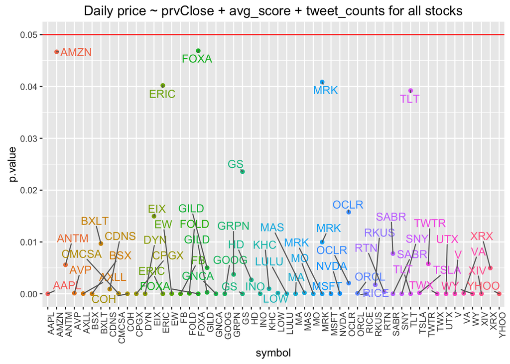